# {{ page.title | escape }} Gradient-Guided Optimizer Routing for LLM Adaptation

## Within 1.5 points of the better baseline in every setting

MoLF stays close to FFT on Fact and to tuned LoRA on Med without choosing a method in advance, and it has the top score of the three in three of the nine settings.

FFTLoRA, best rankMoLFwithin 1.5 pts of the better baseline

### 8B math reasoning

+10.93 vs. LoRA-128

Meta-Llama-3-8B, trained for one epoch on 34,702 ODA-Mixture-100k examples, with every method at learning rate 5e-5 and one training run each. On MATH-500, averaged over three generation seeds, MoLF beats LoRA-128 by 10.93 points (95% interval over evaluation problems: 8.40 to 13.40) and trails FFT by 1.40 (MoLF minus FFT: −3.87 to 1.00, which includes zero). LoRA hits the 7,168-token generation cap in 70.2% of generations, against 58.5% for FFT and 60.1% for MoLF, so part of its gap may come from not finishing within the window.

### Five training seeds on CounterFact

74.57 ± 0.87

These are separate runs on Qwen2.5-1.5B with fixed settings, not repeats of the runs charted above. Over five seeds (mean ± SD), MoLF scores 74.57 ± 0.87, FFT 71.04 ± 2.58 and LoRA-128 70.35 ± 0.49. MoLF beats LoRA-128 on all five paired seeds and FFT on four of five, but the paired 95% interval against FFT (−0.24 to +7.29) includes zero, and FFT runs at a different learning rate. A rank-256 LoRA, whose key and value adapters can reach full rank, scores 74.59 ± 0.87, close to MoLF. That is compatible with capacity, rather than routing alone, driving MoLF's lead over LoRA-128.

05 · Inside the router training dynamics

## Most projections commit to one pathway early

The router can switch any module at any step, but it rarely does. The aggregate mix usually settles within about 500 steps, and most modules stay with one pathway for the rest of training. In the two settings we broke down by projection type, four of the seven types send at least 99% of their updates to one pathway.

Update went to FFTUpdate went to LoRA

Key and value projections take the dense update every time. Gate and up projections take the LoRA update more than 99% of the time. Down projections mostly go dense and output projections mostly LoRA, while the LoRA share of query projections moves with the setting: 77 to 83% on Med, 96 to 97% on Fact. The ranges span five EPD seeds per setting. EPD depends on parameter count and gradient scale, so part of this pattern can come from the shapes of the matrices rather than the task.

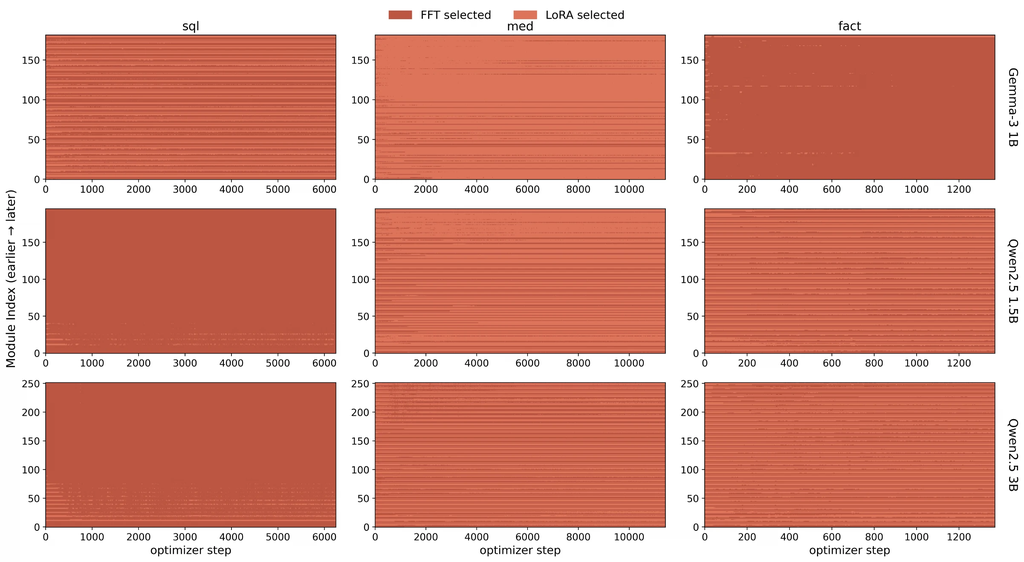

**Figure 6 of the paper.** Each row is one module, each column an optimizer step, and the color is the pathway that took the update (darker: FFT, lighter: LoRA). The horizontal bands mean modules commit early. Med leans LoRA on Gemma-3-1B and Qwen2.5-1.5B and splits about evenly on Qwen2.5-3B; Fact and SQL vary with the backbone.

### Does the choice matter?

Two ablations pull apart the two things MoLF does. Updating both pathways at every step (K = 2) removes the restriction to one update, which also doubles the number of weight updates; a coin flip keeps one update per module but picks it at random.

### Updating both pathways

Update both (K = 2)Top-1, PFN scoreTop-1, EPD score

### EPD against a fair coin

EPD ahead on 4 of 5 seeds

EPDCoin flip

On Qwen2.5-3B MedMCQA, with the update count matched at one pathway per module per step and the same initialization and data order, a coin flip lands within 1.9 points of EPD on four of five seeds and collapses to 33.44 on seed 44. EPD is ahead on four of five seeds and leads by 5.90 points on average; without seed 44, the lead is 0.68 points, with EPD ahead on three of four. The results favor the informed choice in this setting, but the size of its gain is uncertain, and one collapse is not enough to call EPD more stable.

06 · Limits

## What MoLF costs, and what is still open

Top-1 routing skips a pathway's weight update, not its computation. Standard MoLF keeps FFT's dense gradients and Adam state and adds a rank-128 pathway, so it stores at least FFT's training state and gives none of LoRA's memory savings. Inference costs nothing extra, because the LoRA pathway merges into the dense weights.

### Overhead over FFT, Qwen3-8B-Base on eight H100s

19.6% → 9.4% step time

Step timePeak memory

Step-time overhead falls from 19.6% at a 4K-token context to 9.4% at 32K as token compute grows, while peak memory overhead rises from 0.7% to 10.6%. In a separate benchmark on one H100, with a different model, precision and software stack (Qwen2.5-7B, 512 tokens per step), a MoLF step takes 63.8% longer than an FFT step. The two setups are not points on one curve, and both use the current implementation, which has not been optimized for speed.

### Open problems

1. An efficient MoLF is the biggest open problem: a version that keeps MoLF's accuracy at a LoRA-like memory cost. MoLF-E in the paper freezes the base model and routes between two LoRA adapters, which saves memory but drops the dense pathway, so it no longer chooses between FFT and LoRA.
2. EPD is a first-order heuristic, and it is not rank-invariant. At equal learning rates and LoRA scaling constants, a rank-r pathway can get roughly a √(128/r) higher EPD score than a rank-128 one. Rank-aware scores, learning rates and routing priors are untested.
3. Larger candidate pools could adapt more finely, for example several ranks, or coordinate-sparse updates that restrict which entries change instead of the rank. Each candidate adds forward and backward work and optimizer state.
4. Can routing design the architecture? The overall routing mix usually settles within about 500 steps and most modules commit to one pathway early, so a short burn-in might already show which projections the router prefers to update densely and which with low rank. We think this is a very interesting direction, and it may reach past fine-tuning. [Multi-head latent attention](https://arxiv.org/abs/2405.04434) (MLA), from DeepSeek-V2, switches the key and value projections to low-rank factors that share one latent, a choice made by hand. A router like MoLF's could make the dense-or-low-rank part of that choice from gradients, one projection at a time, and perhaps reinvent MLA-style designs or find new ones. Several pieces are still missing: we have not shown that early routing predicts what works best, EPD needs a correction for matrix shape, a shared latent needs candidates that span several projections, and fine-tuning may answer a different question than architecture design. The evidence so far is mixed: in the two settings we broke down by projection type, the router kept every key and value update dense, while on Gemma-3-1B Med most key and value updates went to LoRA. MLA, by contrast, makes the key and value weights themselves low rank.

[figure not shown]

   make K and V low rank with a shared latent**→**

[figure not shown]

   **A sketch of the idea.** In MoLF, every projection has a dense pathway W and a low-rank pathway B·A, and the router updates one of them at each step. In MLA-style attention, the key and value projections become low-rank factors that share one down-projection A, so the cache holds the small latent c instead of full keys and values. The sketch leaves out two details of DeepSeek-V2: it compresses Q too, and it also caches a small decoupled RoPE key.

Code

## Try it

The code is a small PyTorch package: the MoLF wrapper, the sparse AdamW optimizer, both score functions, and the FFT and LoRA baselines. One command fine-tunes, merges the LoRA pathway into the base linears and runs the evaluator.

```
git clone https://github.com/11785T23/molf.git && cd molf
pip install -e .
# train.py logs to Weights & Biases
export WANDB_ENTITY=<your-entity> WANDB_PROJECT=molf
torchrun --nnodes 1 --nproc_per_node=1 src/script/train.py \
    --model_name_or_path Qwen/Qwen2.5-1.5B --dataset_type med \
    --mode molf --molf_score_fn true_projected --molf_topk 1 \
    --molf_lora_ranks "[128]" --use_rslora True \
    --learning_rate 5e-5 --lora_learning_rate 5e-5 \
    --weight_decay 0.1 --lora_weight_decay 0.01 \
    --per_device_batch_size 8 --gradient_accumulation_steps 4 \
    --num_train_epochs 2 --lr_scheduler_type cosine --warm_up_ratio 0.1 \
    --ckpt_dir_root ckpts/molf
```

`--dataset_type` takes `sql`, `med` or `fact`, and `--mode fft` or `--mode lora` runs the baselines. The per-step routing log, `molf_expert_selection.jsonl`, lands next to the merged checkpoint.

### Citation

```
@inproceedings{tang2026molf,
  title={Beyond {LoRA} vs. Full Fine-Tuning: Gradient-Guided Optimizer Routing for {LLM} Adaptation},
  author={Tang, Haozhan and Zhu, Xiuqi and Zhang, Xinyin and Li, Boxun and Smith, Virginia and Kuo, Kevin},
  booktitle={The Fortieth Annual Conference on Neural Information Processing Systems},
  year={2026},
  url={https://arxiv.org/abs/2605.07111}
}
```